# Predict game sales on Steam early access program

Signature Project-Ruiming Wang

# Business Understanding and goal of this project.

Steam is one of the most popular digital distribution platforms on the video game market.

Steam creates a funding model called “Early access”. Allowing game developer release their game to the public before the game development is finished.

“Early access” makes it possible for developers who have fewer resources to finding a new way to fund their development.

However, despite some game developers do deliver some great games. A lot of games are poorly made and the game developers stop developing the game. The game can be dead before it is officially released and it would be a waste of money for the consumers.

The goal of this project is forcast how well can a early access game.

The data for this program I need are owners count, positive review count and negative review count and current player daily peak count for the first month of the game release. And the youtube view three months before the game is released and the first month of the game release.

I’m going to predict the owner count after the game is released on early access for three months.

# Data collecting before data understanding

I will collect data from steamspy.com. The site uses an application programming interface (API) to the Steam software distribution service that is owned by Valve Corporation to estimate the number of sales of software titles offered on the service. Estimates are made based on the API polling user profiles from Steam to determine what software titles (primarily video games) they own and using statistics to estimate overall sales.

The site also provide the data I needed like youtube view for the project.

In order to access the data I needed, I access the early access game list with the api provided by steam spy and created a web crawler with python to access those data. You can find the python code and the raw data I get from the website in my submission.

I Choose to use the data released from March 2017 to September 2017.Because I can access those data the data I need for both building the model and evaluate them.

# Data Understanding and Data Preparation

## Importing the data

```r
release_detail<- read.csv("data\\game_release_date.csv")
for(i in nrow(release_detail))
{
  release_detail$appid[i] = toString(release_detail$appid[i])
}
release_detail$date <- as.Date(release_detail$date)
summary(release_detail)
```

```
    appid                date                price
 Length:139         Min.   :2017-03-01   Min.   : 0.49
 Class :character   1st Qu.:2017-05-11   1st Qu.: 5.99
 Mode  :character   Median :2017-07-21   Median : 9.99
                    Mean   :2017-07-05   Mean   :12.11
                    3rd Qu.:2017-08-25   3rd Qu.:16.99
                    Max.   :2017-09-29   Max.   :34.99
```

```r
str(release_detail$date)
```

```
 Date[1:139], format: "2017-03-23" "2017-05-10" "2017-08-22" "2017-07-20" "2017-07-27" "2017-04-28" "2017-07-26" "2017-05-18" "2017-04-28" "2017-03-06" ...
```

Import the game category.

```r
library(dplyr)
data_detail<- function(appid){

      path <- paste("data\\",appid,sep = "")
      path <- paste(path,"owners.csv",sep = "_")
      detail <- read.csv(path)
      detail$date <- as.Date(detail$date)


      temppath <- paste("data\\",appid,sep = "")
      temppath <- paste(temppath,"positive_reviews.csv",sep = "_")
      temp <- read.csv(temppath)
      temp$date <- as.Date(temp$date)
      detail <- left_join(detail,temp,by = "date")

      temppath <- paste("data\\",appid,sep = "")
      temppath <- paste(temppath,"negative_reviews.csv",sep = "_")
      temp <- read.csv(temppath)
      temp$date <- as.Date(temp$date)
      detail <- left_join(detail,temp,by = "date")

            temppath <- paste("data\\",appid,sep = "")
      temppath <- paste(temppath,"cuu.csv",sep = "_")
      temp <- read.csv(temppath)
      temp$date <- as.Date(temp$date)
      detail <- left_join(detail,temp,by = "date")

            temppath <- paste("data\\",appid,sep = "")
      temppath <- paste(temppath,"youtube.csv",sep = "_")
      temp <- read.csv(temppath)
      temp$date <- as.Date(temp$date)
      detail <- full_join(detail,temp,by = "date")

      detail<-detail[order(detail$date),]

      temppath <- paste("detail_data\\",appid,sep = "")
      temppath <- paste(temppath,".csv",sep = "")
      write.csv(detail, file =temppath,row.names=FALSE)
}
```

Create funciton to combine all features together.

```r
lapply(release_detail$appid,data_detail)
```

Create didicated csv file with every app.

```r
getGame<- function(appid){
  appid
  temppath <- paste("detail_data\\",appid,sep = "")
  temppath <- paste(temppath,".csv",sep = "")
  temp<- read.csv(temppath)
  temp$date <- as.Date(temp$date)
      return(temp)
}
```

```r
getFromRelease<-function(appid){
  temp<-getGame(appid)
  releasedate<- release_detail$date[which(release_detail$appid==appid)]
  if(releasedate<temp$date[1])
    return(temp)
  startposition
  for( i in 1:nrow(temp)){
    startposition = i
    if(temp$date[i]==releasedate){
      break()
    }
  }
  return(temp[c(startposition:nrow(temp)),])
}
```

Create a function access the csv file.

### Data UnderStanding #1

First I want to look at the sales of the game I get from steamspy.

```r
ownership <- data.frame(appid=character(),
               owners=integer(),
               stringsAsFactors=FALSE)
for(appid in release_detail$appid){
  gamedetail<-getGame(appid)
#I'm not trying to get around with imputing data, the data is organized in a way that include the date before the game is realeased.(so I can access the youtube video view before the game veiw)
  gamedetail<-gamedetail[complete.cases(gamedetail),]
  r<- c(appid,gamedetail$owners[90])
  ownership[nrow(ownership)+1,]<- r
}
ownership$owners = as.numeric(ownership$owners)
summary(ownership)
```

```
    appid               owners
 Length:139         Min.   :      0
 Class :character   1st Qu.:    959
 Mode  :character   Median :   2218
                    Mean   :  42224
                    3rd Qu.:   5622
                    Max.   :3675597
                    NA's   :20
```

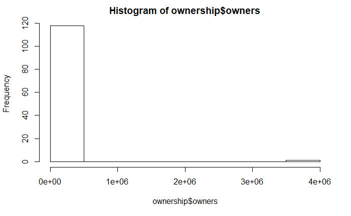

```r
hist(ownership$owners)
```

Apparently there is an outlier. To get a better feel at the data, I will exclude the outlier first. There are also some game with owner of NA or 0. Due to the fact that the webpage on Steamspy can be very unorganized(false realse date, false owner data like data even before the game is realsead on Early access), there is a good chance that the data I fecthed from Steamspy can be faulty. I will exculde those owner with NA or zero too.

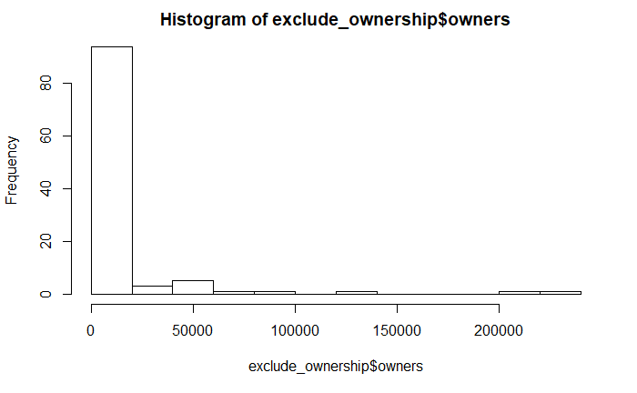

```r
exclude_ownership<- ownership[complete.cases(ownership),]
exclude_ownership <- exclude_ownership[-which(exclude_ownership$owners== 0),]
exclude_ownership <- exclude_ownership[-which(exclude_ownership$owners>1000000),]
hist(exclude_ownership$owners)
```

As we can see, most of the game didn’t sell 50000 copy after the first three months. The goal of this project is to forecast if a game is a disappointment commercial wise.

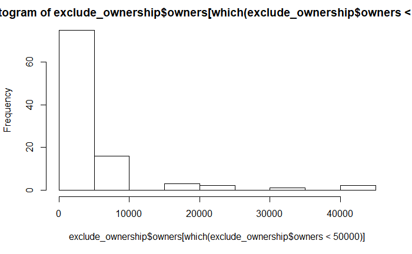

```r
hist(exclude_ownership$owners[which(exclude_ownership$owners<50000)])
```

```r
length(which(exclude_ownership$owners<10000))/length(exclude_ownership)
```

```
[1] 45.5
```

**So the goal of this project is to forecast if a game can sell 10000 copies after 90 days by using the data of 30 days.**

I think this is a meaningful and doable goal for this project.

### Data Preparation #1

```r
library(dplyr)
origin_release<-release_detail
release_detail<-right_join(release_detail,exclude_ownership,by = 'appid')
summary(release_detail)
```

```
    appid                date                price           owners
 Length:107         Min.   :2017-03-01   Min.   : 0.49   Min.   :   601
 Class :character   1st Qu.:2017-05-05   1st Qu.: 6.99   1st Qu.:  1155
 Mode  :character   Median :2017-07-15   Median : 9.99   Median :  2624
                    Mean   :2017-06-26   Mean   :12.54   Mean   : 12608
                    3rd Qu.:2017-08-15   3rd Qu.:17.49   3rd Qu.:  6150
                    Max.   :2017-09-28   Max.   :34.99   Max.   :222643
```

```r
release_detail$goal<-0
release_detail$goal[which(release_detail$owners>10000)]<-1
```

# Modeling

I ’m going to use three model to predict the sell of the game using Knn, decision tree and multiple regression.

### Data UnderStanding #2 - Multiple regression

I will build the multiple regression for each game with their own data. Which means I will only look at one game at a time. I will use the count of the positive review, the count of the negative review, the count daily player peak and youtube view to predicting the owner count. I will use the backfitting to eliminate some features. Since Each game is unique and there are too many of them, I can’t guarantee the feature I pick in one game is significant in every game. And I can’t manually go through all the game, so I have to pick one game, decide which feature to use and use keep using that feauter in every game.

```r
gamedetail<-getGame("578080")
#I'm not trying to get around with imputing data, the data is organized in a way that include the date before the game is realeased.(so I can access the youtube video view before the game veiw)
gamedetail<-gamedetail[complete.cases(gamedetail),]
m1 <- lm(owners~ positive_reviews+negative_reviews+cuu+youtube,data = gamedetail)
summary(m1)
```

```
Call:
lm(formula = owners ~ positive_reviews + negative_reviews + cuu +
    youtube, data = gamedetail)

Residuals:
     Min       1Q   Median       3Q      Max
-2725850  -654063    12517   630136  5221107

Coefficients:
                   Estimate Std. Error t value Pr(>|t|)
(Intercept)       2.504e+06  3.618e+05   6.920 3.66e-11 ***
positive_reviews  1.270e+02  3.883e+01   3.270  0.00122 **
negative_reviews  1.328e+02  7.823e+01   1.698  0.09078 .
cuu               7.623e+00  1.124e-01  67.805  < 2e-16 ***
youtube          -9.795e-02  3.566e-02  -2.747  0.00645 **
---
Signif. codes:  0 ‘***’ 0.001 ‘**’ 0.01 ‘*’ 0.05 ‘.’ 0.1 ‘ ’ 1

Residual standard error: 1100000 on 254 degrees of freedom
Multiple R-squared:  0.9758,    Adjusted R-squared:  0.9754
F-statistic:  2559 on 4 and 254 DF,  p-value: < 2.2e-16
```

The R-squared looks pretty good.I will try another game.

```r
#Chose a game with very low owner count
gamedetail<-getGame(release_detail$appid[105])
#I'm not trying to get around with imputing data, the data is organized in a way that include the date before the game is realeased.(so I can access the youtube video view before the game veiw)
gamedetail<-gamedetail[complete.cases(gamedetail),]
gamedetail<- gamedetail[c(1:30),]
m1 <- lm(owners~ positive_reviews+negative_reviews+cuu+youtube+date,data = gamedetail)
summary(m1)
```

```
Call:
lm(formula = owners ~ positive_reviews + negative_reviews + cuu +
    youtube + date, data = gamedetail)

Residuals:
    Min      1Q  Median      3Q     Max
-721.76 -103.04   -4.47  113.48  794.79

Coefficients: (2 not defined because of singularities)
                   Estimate Std. Error t value Pr(>|t|)
(Intercept)      -9.569e+05  1.172e+05  -8.165 1.20e-08 ***
positive_reviews         NA         NA      NA       NA
negative_reviews         NA         NA      NA       NA
cuu              -9.646e+01  3.420e+01  -2.820  0.00907 **
youtube           1.121e-02  2.187e-03   5.127 2.40e-05 ***
date              5.541e+01  6.788e+00   8.164 1.21e-08 ***
---
Signif. codes:  0 ‘***’ 0.001 ‘**’ 0.01 ‘*’ 0.05 ‘.’ 0.1 ‘ ’ 1

Residual standard error: 262.7 on 26 degrees of freedom
Multiple R-squared:  0.8484,    Adjusted R-squared:  0.8309
F-statistic: 48.51 on 3 and 26 DF,  p-value: 8.644e-11
```

This one is not that good. Lets look at a game with higher owner count.

```r
#Chose a game with  15095 owner count
gamedetail<-getGame(release_detail$appid[22])
#I'm not trying to get around with imputing data, the data is organized in a way that include the date before the game is realeased.(so I can access the youtube video view before the game veiw)
gamedetail<-gamedetail[complete.cases(gamedetail),]
gamedetail<- gamedetail[c(1:30),]
m1 <- lm(owners~ positive_reviews+negative_reviews+cuu+youtube+date,data = gamedetail)
summary(m1)
```

```
Call:
lm(formula = owners ~ positive_reviews + negative_reviews + cuu +
    youtube + date, data = gamedetail)

Residuals:
    Min      1Q  Median      3Q     Max
-3925.7 -1055.6  -403.7   806.6  5440.2

Coefficients:
                   Estimate Std. Error t value Pr(>|t|)
(Intercept)      -6.364e+06  9.423e+05  -6.753 5.51e-07 ***
positive_reviews -8.439e+01  6.461e+01  -1.306   0.2038
negative_reviews -2.220e+00  9.603e+01  -0.023   0.9817
cuu               8.995e+00  3.967e+00   2.267   0.0327 *
youtube           1.212e-02  2.051e-02   0.591   0.5601
date              3.658e+02  5.412e+01   6.760 5.43e-07 ***
---
Signif. codes:  0 ‘***’ 0.001 ‘**’ 0.01 ‘*’ 0.05 ‘.’ 0.1 ‘ ’ 1

Residual standard error: 2323 on 24 degrees of freedom
Multiple R-squared:  0.7157,    Adjusted R-squared:  0.6565
F-statistic: 12.08 on 5 and 24 DF,  p-value: 6.406e-06
```

```r
#Chose a game with very high owner count
gamedetail<-getGame(release_detail$appid[2])
#I'm not trying to get around with imputing data, the data is organized in a way that include the date before the game is realeased.(so I can access the youtube video view before the game veiw)
gamedetail<-gamedetail[complete.cases(gamedetail),]
gamedetail<- gamedetail[c(1:30),]
m1 <- lm(owners~ positive_reviews+negative_reviews+cuu+youtube+date,data = gamedetail)
summary(m1)
```

```
Call:
lm(formula = owners ~ positive_reviews + negative_reviews + cuu +
    youtube + date, data = gamedetail)

Residuals:
   Min     1Q Median     3Q    Max
-13803  -3810   1560   4112   8744

Coefficients:
                   Estimate Std. Error t value Pr(>|t|)
(Intercept)      -3.072e+07  4.186e+06  -7.340 1.40e-07 ***
positive_reviews -1.090e+02  4.341e+01  -2.511   0.0192 *
negative_reviews -3.422e+02  1.499e+02  -2.283   0.0316 *
cuu               7.617e+00  6.637e+00   1.148   0.2625
youtube           1.699e-02  1.385e-02   1.226   0.2320
date              1.766e+03  2.401e+02   7.356 1.35e-07 ***
---
Signif. codes:  0 ‘***’ 0.001 ‘**’ 0.01 ‘*’ 0.05 ‘.’ 0.1 ‘ ’ 1

Residual standard error: 6208 on 24 degrees of freedom
Multiple R-squared:  0.8846,    Adjusted R-squared:  0.8605
F-statistic: 36.78 on 5 and 24 DF,  p-value: 1.714e-10
```

I realized some game don’t have any review at all due to the low owner count at the very begining and different game has a has different significant feature. The safe bet should be build different model based on the different model. And select the model with biggest Adjusted R-squared.

The three set of feature I’m going to use are:

- Date,positive_reviews,negative_reviews
- Date,cuu
- Date,youtube,cuu

### Data Preparation #2 - Multiple regression

All set.

### Modeling #2 - Multiple regression

```r
multi_regression <- data.frame(appid=character(),
               rsquare=numeric(),
               owners_predict=numeric(),
               stringsAsFactors=FALSE)
for(appid in release_detail$appid){
  gamedetail<-getFromRelease(appid)
  gamedetail<-gamedetail[complete.cases(gamedetail),]
  train_gamedetail<- gamedetail[c(1:30),]

  m1 <- lm(owners~ positive_reviews+negative_reviews+date,data = train_gamedetail)
  summary(m1)$adj.r.squared
  m1.predict <- predict(m1,gamedetail[90,])

    m2 <- lm(owners~ cuu+date,data = train_gamedetail)
  summary(m2)$adj.r.squared
  m2.predict <- predict(m2,gamedetail[90,])

    m3 <- lm(owners~cuu+youtube+date,data = train_gamedetail)
  summary(m3)$adj.r.squared
  m3.predict <- predict(m3,gamedetail[90,])

  finaladj.r=0
  finalowners=0
  if(summary(m1)$adj.r.squared>summary(m2)$adj.r.squared)
  {
    finaladj.r = summary(m1)$adj.r.squared
    finalowners = m1.predict
  }
  else{
    finaladj.r = summary(m2)$adj.r.squared
    finalowners = m2.predict
  }

  if(summary(m3)$adj.r.squared>finaladj.r)
  {
    finaladj.r = summary(m3)$adj.r.squared
    finalowners = m3.predict
  }

  r<- c(appid,finaladj.r,finalowners)
  multi_regression[nrow(multi_regression)+1,]<- r
}
```

Train model.

### Evaluation #2 - Multiple regression

```r
multi_regression[is.na(multi_regression)]<-0
multi_regression$goal <-0
multi_regression$goal[which(multi_regression$owners_predict>10000)]<-1
length(which(multi_regression$goal==release_detail$goal))/nrow(release_detail)
```

```
[1] 0.2429907
```

The overall correct rate is 24%. But there are a lot of instance with very low adjusted r square.

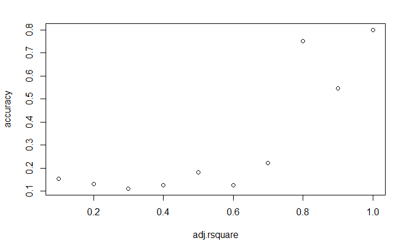

```r
MulRHist <- data.frame(adj.rsquare = numeric(),
               accuracy = numeric(),
               stringsAsFactors=FALSE)
for(i in 1:10){
  target<-which(multi_regression$rsquare>(i-1)*0.1&multi_regression$rsquare<(i*0.1))


  r<- c(i*0.1,length(which(multi_regression$goal[target]==release_detail$goal[target]))/nrow(release_detail[target,]))
  MulRHist[nrow(MulRHist)+1,]<- r

}
plot(MulRHist)
```

According to the graph, the accuracy is very high when adjusted r-square is between 0.7~0.8 and 0.9~1.0. This model provides to be useful in certain situation.

I need another two model to make up for the rest of the part. And create a stacked ensemble model that combines these three model together.

# Modeling

I ’m going to use three model to predict the sell of the game using Knn, decision tree and multiple regression.

### Data UnderStanding #3 - Decision Tree

In this model I will include pre release youtube video view, Peak daily concurrent players(cuu), youtube view after release owners, positive and negative review,price.

### Data Preparation #3 - Decision Tree

#### Pre release youtube video view.

I’m going to take youtube video view as a factor when I want to predict the game sale. And video view pre game release is something very special. It represents how well the game is marketed. Some game in my selection is not marked at all. So I’m going to transform the pre game release video view as a factor. The level of factor will be k+1. k for using k means cluster and plus one for games that have no youtube view by release.

Due to SteamSpy doesn’t collect all the pre release youtube view data completely, I’m going to use Three elments to mesure the data.

- Max daily view number. The peak of youtube video viewed in a day.
- First appearance The number of days first video on youtube come out before the game was released.
- Median that exclude zero view. Due to the fact that SteamSpy didn’t do a good job to pre release youtube view data, I’m going to ignore the data with zero view.

By using these three freatures. **I’m going to create very simple a 4 means cluster to represent how well the game is marketed on internet.**

```r
youtube_prerelease <- data.frame(appid=character(),
               market_level=integer(),
               non_zero_median = integer(),
               max_view = integer(),
               first_appearance = integer(),
               stringsAsFactors=FALSE)
for (appid in release_detail$appid)
{
  temp<- getGame(appid)
  #Check if there are any youtube views before the game release.
  if(is.na(temp$owners[1])){
    r<- c(appid,0,median(temp$youtube[which(temp$youtube!=0)]),max(temp$youtube),length(which(is.na( temp$owners))))
    youtube_prerelease[nrow(youtube_prerelease)+1,]<- r
  }
  else{
        r<- c(appid,-1,0,0,0)
    youtube_prerelease[nrow(youtube_prerelease)+1,]<- r
  }

}
youtube_prerelease[is.na(youtube_prerelease)] <- 0
```

Get the pre release video data ready.

```r
clus<- kmeans(youtube_prerelease[which(youtube_prerelease$market_level!=-1),-c(1,2)],centers = 4)
```

```r
a=clus$cluster
a = as.data.frame(a)
b = as.numeric(rownames(a))
a$rownamenumeric<-b
temp<-youtube_prerelease
b = as.numeric(rownames(temp))
temp$rownamenumeric<-b
temp <- full_join(temp,a,by='rownamenumeric')
temp[is.na(temp)]<-0
youtube_prerelease$market_level<-as.factor(temp$a)
#release_detail$market_level<- as.factor(temp$a)
```

Use 4 centers kmean. Create dummy code to market_level

```r
library(psych)
decision_tree_data<- data.frame(appid = release_detail$appid , price = release_detail$price,stringsAsFactors=FALSE )
market_level_dummy <- as.data.frame(dummy.code(youtube_prerelease$market_level))
decision_tree_data<- cbind(decision_tree_data,market_level_dummy)
str(decision_tree_data)
```

```
'data.frame':   107 obs. of  7 variables:
 $ appid: chr  "588650" "611500" "529180" "529240" ...
 $ price: num  16.99 29.99 29.99 1.99 24.99 ...
 $ 0    : num  0 1 0 0 1 1 1 1 0 1 ...
 $ 1    : num  1 0 0 0 0 0 0 0 0 0 ...
 $ 2    : num  0 0 0 0 0 0 0 0 0 0 ...
 $ 3    : num  0 0 1 0 0 0 0 0 1 0 ...
 $ 4    : num  0 0 0 1 0 0 0 0 0 0 ...
```

Add dummy code, price and appid to a new data frame that hold the feature we need to build the model.

#### Youtube view, cuu and review after the game is release.

For those feature, I will pick two time node: A week after release and a month after release. The first week usually is when the game recieved most attention and sold most copy. And I include the first month because I want to expose more data to my model.

```r
decision_tree_data$week_youtube<-0
decision_tree_data$month_youtube<-0
decision_tree_data$week_P_review<-0
decision_tree_data$month_P_review<-0
decision_tree_data$week_cuu<-0
decision_tree_data$month_cuu<-0
decision_tree_data$week_N_review<-0
decision_tree_data$month_N_review<-0
for(appid in release_detail$appid){
  gamedetail<- getFromRelease(appid)
  gamedetail <-gamedetail[complete.cases(gamedetail),]
  decision_tree_data$week_youtube[which(decision_tree_data$appid==appid)] = sum(gamedetail$youtube[c(1:7)])
  decision_tree_data$month_youtube[which(decision_tree_data$appid==appid)] = sum(gamedetail$youtube[c(1:30)])

    decision_tree_data$week_P_review[which(decision_tree_data$appid==appid)] = sum(gamedetail$positive_reviews[c(1:7)])
  decision_tree_data$month_P_review[which(decision_tree_data$appid==appid)] = sum(gamedetail$positive_reviews[c(1:30)])

    decision_tree_data$week_cuu[which(decision_tree_data$appid==appid)] = gamedetail$cuu[7]
  decision_tree_data$month_cuu[which(decision_tree_data$appid==appid)] = gamedetail$cuu[30]

    decision_tree_data$week_N_review[which(decision_tree_data$appid==appid)] = sum(gamedetail$negative_reviews[c(1:7)])
  decision_tree_data$month_N_review[which(decision_tree_data$appid==appid)] = sum(gamedetail$negative_reviews[c(1:30)])

}
summary(decision_tree_data)
```

```
    appid               price             0                1                 2                 3                 4
 Length:107         Min.   : 0.49   Min.   :0.0000   Min.   :0.00000   Min.   :0.00000   Min.   :0.00000   Min.   :0.0000
 Class :character   1st Qu.: 6.99   1st Qu.:0.0000   1st Qu.:0.00000   1st Qu.:0.00000   1st Qu.:0.00000   1st Qu.:0.0000
 Mode  :character   Median : 9.99   Median :0.0000   Median :0.00000   Median :0.00000   Median :0.00000   Median :0.0000
                    Mean   :12.54   Mean   :0.4206   Mean   :0.06542   Mean   :0.01869   Mean   :0.03738   Mean   :0.4579
                    3rd Qu.:17.49   3rd Qu.:1.0000   3rd Qu.:0.00000   3rd Qu.:0.00000   3rd Qu.:0.00000   3rd Qu.:1.0000
                    Max.   :34.99   Max.   :1.0000   Max.   :1.00000   Max.   :1.00000   Max.   :1.00000   Max.   :1.0000
  week_youtube      month_youtube       week_P_review    month_P_review      week_cuu         month_cuu      week_N_review
 Min.   :       0   Min.   :        0   Min.   :   0.0   Min.   :   0.0   Min.   :    0.0   Min.   :   0.0   Min.   :-1197.00
 1st Qu.:     973   1st Qu.:     5624   1st Qu.:   0.0   1st Qu.:   0.0   1st Qu.:    2.0   1st Qu.:   1.0   1st Qu.:  -12.50
 Median :   14940   Median :   101778   Median :   6.0   Median :  18.0   Median :    6.0   Median :   5.0   Median :    0.00
 Mean   :  914007   Mean   :  4325401   Mean   : 108.2   Mean   : 190.1   Mean   :  298.4   Mean   : 147.9   Mean   :  -31.79
 3rd Qu.:  325071   3rd Qu.:   900080   3rd Qu.:  64.5   3rd Qu.:  94.0   3rd Qu.:   37.5   3rd Qu.:  26.0   3rd Qu.:    0.00
 Max.   :37744448   Max.   :149008552   Max.   :2319.0   Max.   :4632.0   Max.   :10187.0   Max.   :6573.0   Max.   :    1.00
 month_N_review
 Min.   :-2154.00
 1st Qu.:  -18.00
 Median :   -2.00
 Mean   :  -56.15
 3rd Qu.:    0.00
 Max.   :    1.00
```

```r
decision_tree_data$goal <- as.factor(release_detail$goal)
```

#### Create training and testing data set.

I’m going to use the 3-fold cross validation.

```r
summary(as.factor(release_detail$goal))
```

```
 0  1
91 16
```

```r
failgame<-decision_tree_data[ which(release_detail$goal==0),]
fld_fail <- split(failgame, sample(1:3, nrow(failgame), replace=T))
successgame<-decision_tree_data[ which(release_detail$goal==1),]
fld_scc <- split(successgame, sample(1:3, nrow(successgame), replace=T))
data_set = as.list(1:3)

for(i in 1:3){
  data_set[[i]]= rbind(fld_fail[[i]],fld_scc[[i]])
}
```

### Modeling #3 - Decision Tree

```r
library(C50)
library(gmodels)
for(i in 1:1){
  testset<- data_set[[i]]
  firsttime=0
  for(j in 1:3){
    if(j!=i){
      if(firsttime==0){
        firsttime =  1
        trainset = data_set[[j]]
      }
      else
        trainset = rbind(trainset,data_set[[j]])
    }
  }
  decision_tree_model<- C5.0(trainset[-c(1,16)],y = trainset$goal,trials=10)
    tree_pred<-predict(decision_tree_model,testset[-c(1,16)])
  CrossTable(testset$goal,tree_pred)
}
```

```
   Cell Contents
|-------------------------|
|                       N |
| Chi-square contribution |
|           N / Row Total |
|           N / Col Total |
|         N / Table Total |
|-------------------------|


Total Observations in Table:  38


             | tree_pred
testset$goal |         0 |         1 | Row Total |
-------------|-----------|-----------|-----------|
           0 |        33 |         1 |        34 |
             |     0.409 |     2.697 |           |
             |     0.971 |     0.029 |     0.895 |
             |     1.000 |     0.200 |           |
             |     0.868 |     0.026 |           |
-------------|-----------|-----------|-----------|
           1 |         0 |         4 |         4 |
             |     3.474 |    22.926 |           |
             |     0.000 |     1.000 |     0.105 |
             |     0.000 |     0.800 |           |
             |     0.000 |     0.105 |           |
-------------|-----------|-----------|-----------|
Column Total |        33 |         5 |        38 |
             |     0.868 |     0.132 |           |
-------------|-----------|-----------|-----------|
```

### Evaluation #3 - Decision Tree

When building the model I tried one of the combination of data set. Right now I’m using the 3-fold cross-validation.

```r
library(C50)
library(gmodels)
correct_count=0
for(i in 1:3){
  testset<- data_set[[i]]
  firsttime=0
  for(j in 1:3){
    if(j!=i){
      if(firsttime==0){
        firsttime =  1
        trainset = data_set[[j]]
      }
      else
        trainset = rbind(trainset,data_set[[j]])
    }
  }
  decision_tree_model<- C5.0(trainset[-c(1,16)],y = trainset$goal,trials=10)
    tree_pred<-predict(decision_tree_model,testset[-c(1,16)])
  correct_count = correct_count+ length(which(testset$goal==tree_pred))
}
correct_count/nrow(decision_tree_data)
```

```
[1] 0.9813084
```

This accuracy of this model is 98%

### Data Preparation #4 - Knn

I’m going to use the same data that build decision tree.

### Data Preparation #4 - Knn

Before build the model, I’m going to nomarlize the data.

```r
normalize<- function(x){
  return( (x-min(x)) /(max(x)-min(x)))
}
```

```r
knn_data<-decision_tree_data
knn_data$price<- normalize(knn_data$price)
knn_data$week_youtube<- normalize(knn_data$week_youtube)
knn_data$month_youtube<- normalize(knn_data$month_youtube)
knn_data$week_P_review<- normalize(knn_data$week_P_review)
knn_data$month_P_review<- normalize(knn_data$month_P_review)
knn_data$week_cuu<- normalize(knn_data$week_cuu)
knn_data$month_cuu<- normalize(knn_data$month_cuu)
knn_data$week_N_review<- normalize(knn_data$week_N_review)
knn_data$month_N_review<- normalize(knn_data$month_N_review)
summary(knn_data)
```

```
    appid               price              0                1                 2                 3                 4
 Length:107         Min.   :0.0000   Min.   :0.0000   Min.   :0.00000   Min.   :0.00000   Min.   :0.00000   Min.   :0.0000
 Class :character   1st Qu.:0.1884   1st Qu.:0.0000   1st Qu.:0.00000   1st Qu.:0.00000   1st Qu.:0.00000   1st Qu.:0.0000
 Mode  :character   Median :0.2754   Median :0.0000   Median :0.00000   Median :0.00000   Median :0.00000   Median :0.0000
                    Mean   :0.3494   Mean   :0.4206   Mean   :0.06542   Mean   :0.01869   Mean   :0.03738   Mean   :0.4579
                    3rd Qu.:0.4928   3rd Qu.:1.0000   3rd Qu.:0.00000   3rd Qu.:0.00000   3rd Qu.:0.00000   3rd Qu.:1.0000
                    Max.   :1.0000   Max.   :1.0000   Max.   :1.00000   Max.   :1.00000   Max.   :1.00000   Max.   :1.0000
  week_youtube       month_youtube       week_P_review      month_P_review        week_cuu           month_cuu         week_N_review
 Min.   :0.0000000   Min.   :0.0000000   Min.   :0.000000   Min.   :0.000000   Min.   :0.0000000   Min.   :0.0000000   Min.   :0.0000
 1st Qu.:0.0000258   1st Qu.:0.0000377   1st Qu.:0.000000   1st Qu.:0.000000   1st Qu.:0.0001963   1st Qu.:0.0001521   1st Qu.:0.9887
 Median :0.0003958   Median :0.0006830   Median :0.002587   Median :0.003886   Median :0.0005890   Median :0.0007607   Median :0.9992
 Mean   :0.0242157   Mean   :0.0290279   Mean   :0.046644   Mean   :0.041031   Mean   :0.0292924   Mean   :0.0225050   Mean   :0.9726
 3rd Qu.:0.0086124   3rd Qu.:0.0060405   3rd Qu.:0.027814   3rd Qu.:0.020294   3rd Qu.:0.0036812   3rd Qu.:0.0039556   3rd Qu.:0.9992
 Max.   :1.0000000   Max.   :1.0000000   Max.   :1.000000   Max.   :1.000000   Max.   :1.0000000   Max.   :1.0000000   Max.   :1.0000
 month_N_review   goal
 Min.   :0.0000   0:91
 1st Qu.:0.9912   1:16
 Median :0.9986
 Mean   :0.9735
 3rd Qu.:0.9995
 Max.   :1.0000
```

```r
failgame<-knn_data[ which(knn_data$goal==0),]
fld_fail <- split(failgame, sample(1:3, nrow(failgame), replace=T))
successgame<-knn_data[ which(knn_data$goal==1),]
fld_scc <- split(successgame, sample(1:3, nrow(successgame), replace=T))
data_set = as.list(1:3)

for(i in 1:3){
  data_set[[i]]= rbind(fld_fail[[i]],fld_scc[[i]])
}
```

Prepare data set for 3-fold cross-validation.

### Modeling #4 - Knn

```r
library(class)
for(i in 1:1){
  testset<- data_set[[i]]
  firsttime=0
  for(j in 1:3){
    if(j!=i){
      if(firsttime==0){
        firsttime =  1
        trainset = data_set[[j]]
      }
      else
        trainset = rbind(trainset,data_set[[j]])
    }
  }
  knn_pred<- knn(train = trainset[-c(1,16)],test = testset[-c(1,16)],cl = trainset$goal,k=7)

  CrossTable(testset$goal,knn_pred)
}
```

```
   Cell Contents
|-------------------------|
|                       N |
| Chi-square contribution |
|           N / Row Total |
|           N / Col Total |
|         N / Table Total |
|-------------------------|


Total Observations in Table:  28


             | knn_pred
testset$goal |         0 |         1 | Row Total |
-------------|-----------|-----------|-----------|
           0 |        23 |         0 |        23 |
             |     0.548 |     3.286 |           |
             |     1.000 |     0.000 |     0.821 |
             |     0.958 |     0.000 |           |
             |     0.821 |     0.000 |           |
-------------|-----------|-----------|-----------|
           1 |         1 |         4 |         5 |
             |     2.519 |    15.114 |           |
             |     0.200 |     0.800 |     0.179 |
             |     0.042 |     1.000 |           |
             |     0.036 |     0.143 |           |
-------------|-----------|-----------|-----------|
Column Total |        24 |         4 |        28 |
             |     0.857 |     0.143 |           |
-------------|-----------|-----------|-----------|
```

#### Evaluation #4 - knn

```r
correct_count=0
for(i in 1:3){
  testset<- data_set[[i]]
  firsttime=0
  for(j in 1:3){
    if(j!=i){
      if(firsttime==0){
        firsttime =  1
        trainset = data_set[[j]]
      }
      else
        trainset = rbind(trainset,data_set[[j]])
    }
  }
  knn_pred<- knn(train = trainset[-c(1,16)],test = testset[-c(1,16)],cl = trainset$goal,k=7)
  correct_count = correct_count+ length(which(testset$goal==knn_pred))

}
correct_count/nrow(knn_data)
```

```
[1] 0.9065421
```

The accuracy of knn model is 90.7%

# Deployment - create a stacked ensemble model

I will use weighted voting to ensemble the model. Since the regression method has a very high accuracy on when adjusted r-squared reach certain level. I will only count the vote of this model when the adjusted r-square is larger than 0.7. When there is only two model left to vote. I will choose the decision tree, because it has a very high accuracy.